# data

## bun_max

| Feature | Result |
| --- | --- |
| Variable type | numeric |
| Number of missing obs. | 2 (0.04 %) |
| Number of unique values | 156 |
| Median | 24 |
| 1st and 3rd quartiles | 16; 39 |
| Min. and max. | 3; 261 |

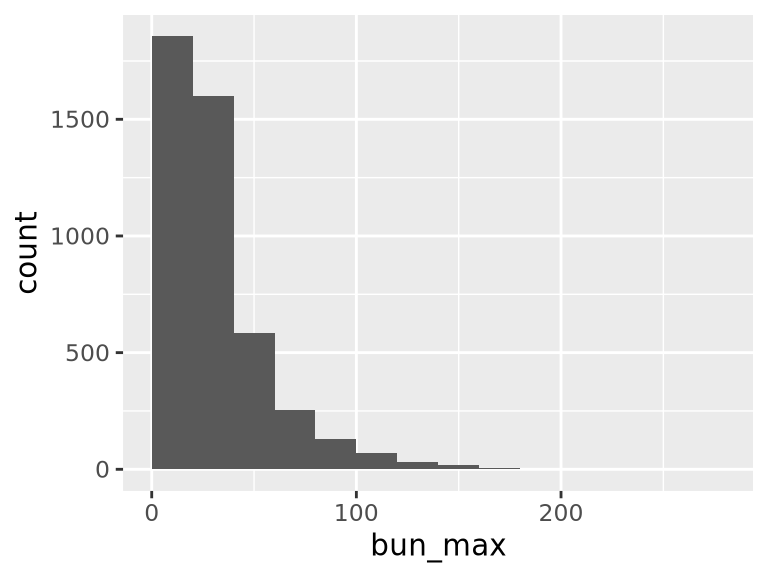

- Note that the following possible outlier values were detected: "3", "4", "5", "6", "7", …, "212", "218", "229", "251", "261" (13 values omitted).

## bun_mean

| Feature | Result |
| --- | --- |
| Variable type | numeric |
| Number of missing obs. | 0 (0 %) |
| Number of unique values | 256 |
| Median | 21.5 |
| 1st and 3rd quartiles | 14.5; 36 |
| Min. and max. | 0; 216.5 |

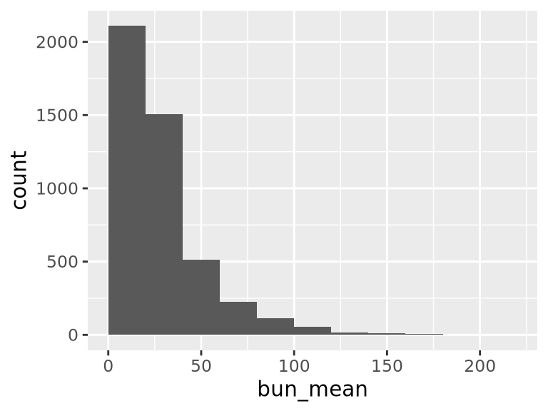

- Note that the following possible outlier values were detected: "0", "2", "3", "3.5", "4", …, "172", "178.5", "194.5", "206.5", "216.5" (19 values omitted).

## wbc_min

| Feature | Result |
| --- | --- |
| Variable type | numeric |
| Number of missing obs. | 5 (0.11 %) |
| Number of unique values | 348 |
| Median | 9.6 |
| 1st and 3rd quartiles | 6.6; 13.4 |
| Min. and max. | 0.1; 336.7 |

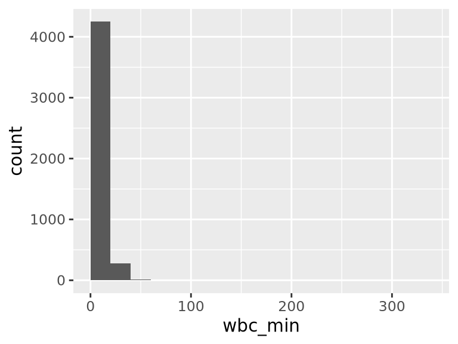

- Note that the following possible outlier values were detected: "0.1", "0.2", "0.3", "0.4", "0.5", …, "86", "87.8", "181.4", "243.6", "336.7" (66 values omitted).

## wbc_max

| Feature | Result |
| --- | --- |
| Variable type | numeric |
| Number of missing obs. | 5 (0.11 %) |
| Number of unique values | 435 |
| Median | 13.6 |
| 1st and 3rd quartiles | 9.7; 18.5 |
| Min. and max. | 0.1; 471.7 |

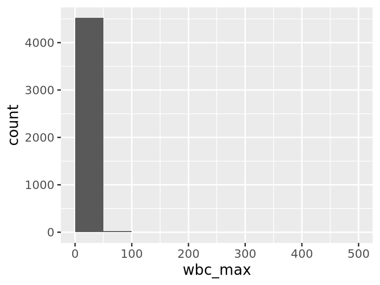

- Note that the following possible outlier values were detected: "0.1", "0.2", "0.3", "0.4", "0.5", …, "126.2", "183", "325.7", "462.6", "471.7" (78 values omitted).

## wbc_mean

| Feature | Result |
| --- | --- |
| Variable type | numeric |
| Number of missing obs. | 0 (0 %) |
| Number of unique values | 658 |
| Median | 11.75 |
| 1st and 3rd quartiles | 8.4; 15.85 |
| Min. and max. | 0; 404.2 |

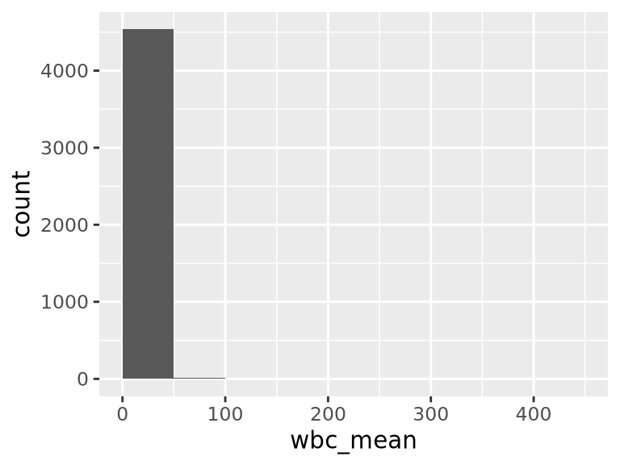

- Note that the following possible outlier values were detected: "0", "0.1", "0.15", "0.2", "0.25", …, "106.1", "182.2", "206.75", "353.1", "404.2" (94 values omitted).

## heartrate_min

| Feature | Result |
| --- | --- |
| Variable type | numeric |
| Number of missing obs. | 0 (0 %) |
| Number of unique values | 114 |
| Median | 72 |
| 1st and 3rd quartiles | 62; 84 |
| Min. and max. | 1; 134 |

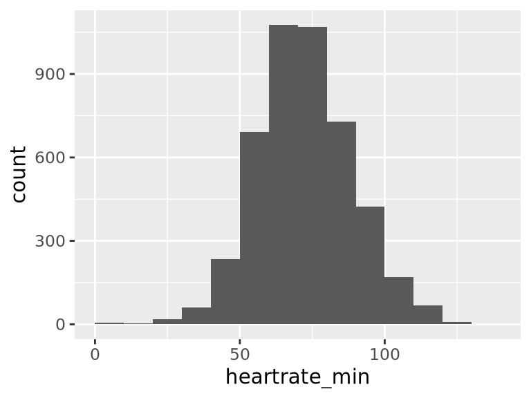

- Note that the following possible outlier values were detected: "1", "3", "4", "5", "8", …, "37", "127", "129", "130", "134" (17 values omitted).

## heartrate_max

| Feature | Result |
| --- | --- |
| Variable type | numeric |
| Number of missing obs. | 0 (0 %) |
| Number of unique values | 131 |
| Median | 106 |
| 1st and 3rd quartiles | 92; 121 |
| Min. and max. | 41; 223 |

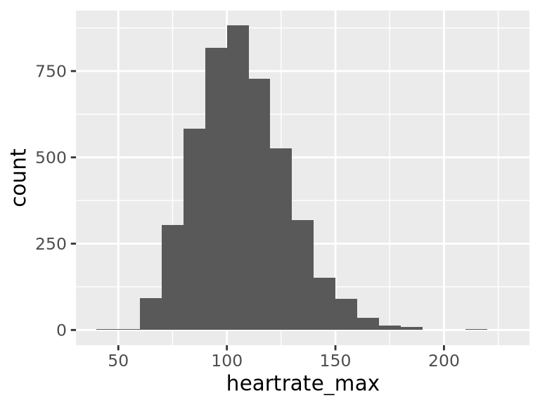

- Note that the following possible outlier values were detected: "41", "49", "50", "53", "55", …, "190", "194", "213", "215", "223" (9 values omitted).

## heartrate_mean

| Feature | Result |
| --- | --- |
| Variable type | numeric |
| Number of missing obs. | 0 (0 %) |
| Number of unique values | 3902 |
| Median | 87.78 |
| 1st and 3rd quartiles | 76.02; 99.75 |
| Min. and max. | 35.78; 154.53 |

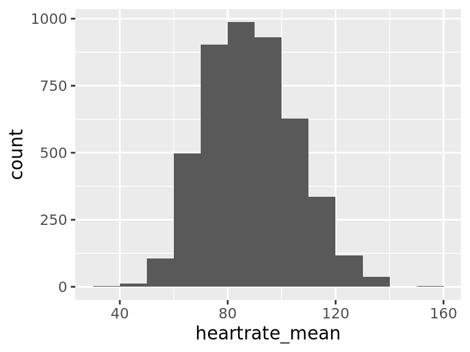

- Note that the following possible outlier values were detected: "35.78", "36", "37.62", "138.48", "138.71", …, "139.14", "139.48", "149.12", "152.22", "154.53" (1 values omitted).

## sysbp_min

| Feature | Result |
| --- | --- |
| Variable type | numeric |
| Number of missing obs. | 8 (0.18 %) |
| Number of unique values | 134 |
| Median | 88 |
| 1st and 3rd quartiles | 79; 98 |
| Min. and max. | 5; 168 |

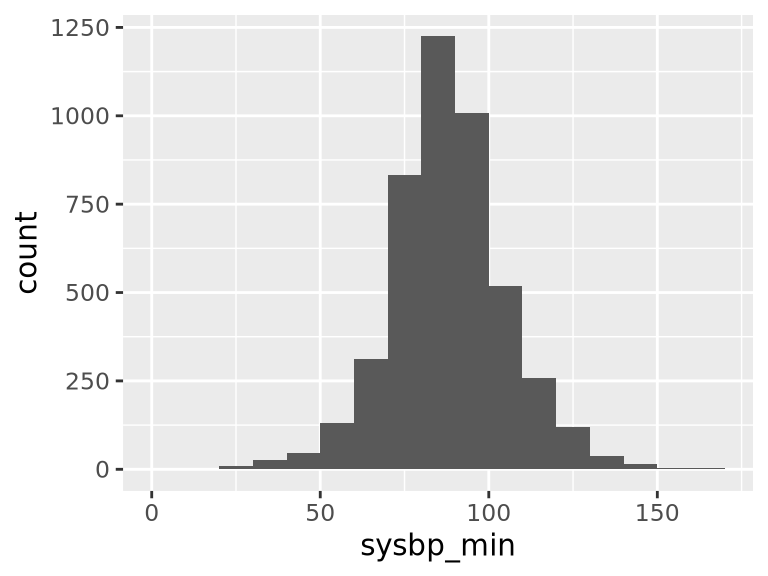

- Note that the following possible outlier values were detected: "5", "10", "18", "22", "23", …, "151", "158", "161", "162", "168" (49 values omitted).

## sysbp_max

| Feature | Result |
| --- | --- |
| Variable type | numeric |
| Number of missing obs. | 8 (0.18 %) |
| Number of unique values | 151 |
| Median | 146 |
| 1st and 3rd quartiles | 132; 162 |
| Min. and max. | 83; 311 |

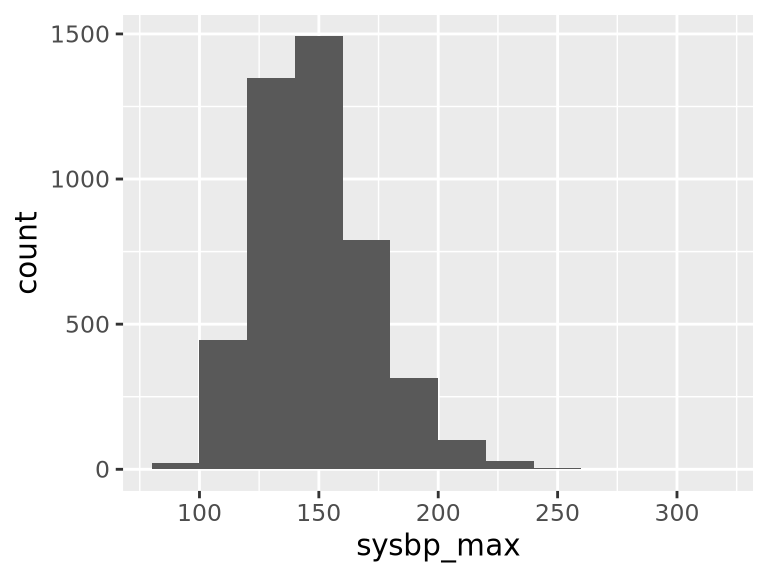

- Note that the following possible outlier values were detected: "83", "89", "90", "91", "92", …, "252", "254", "265", "273", "311" (21 values omitted).

## sysbp_mean

| Feature | Result |
| --- | --- |
| Variable type | numeric |
| Number of missing obs. | 8 (0.18 %) |
| Number of unique values | 3867 |
| Median | 113.61 |
| 1st and 3rd quartiles | 104.89; 125.63 |
| Min. and max. | 69.88; 195.34 |

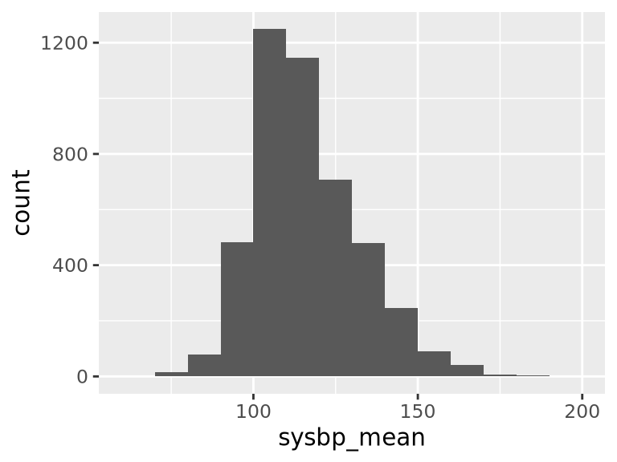

- Note that the following possible outlier values were detected: "69.88", "71.68", "71.73", "73.12", "75.44", …, "180.83", "181.96", "182.48", "188.29", "195.34" (85 values omitted).

## diasbp_min

| Feature | Result |
| --- | --- |
| Variable type | numeric |
| Number of missing obs. | 8 (0.18 %) |
| Number of unique values | 80 |
| Median | 44 |
| 1st and 3rd quartiles | 37; 51 |
| Min. and max. | 5; 114 |

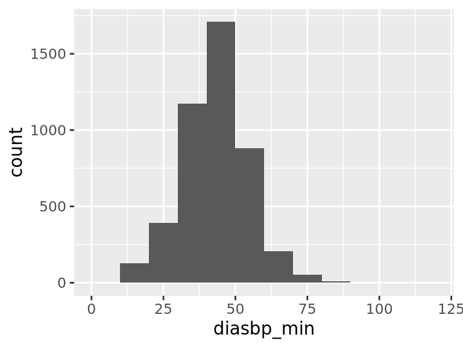

- Note that the following possible outlier values were detected: "5", "6", "11", "12", "13", …, "85", "88", "92", "93", "114" (13 values omitted).

## diasbp_max

| Feature | Result |
| --- | --- |
| Variable type | numeric |
| Number of missing obs. | 8 (0.18 %) |
| Number of unique values | 136 |
| Median | 83 |
| 1st and 3rd quartiles | 73; 96 |
| Min. and max. | 35; 197 |

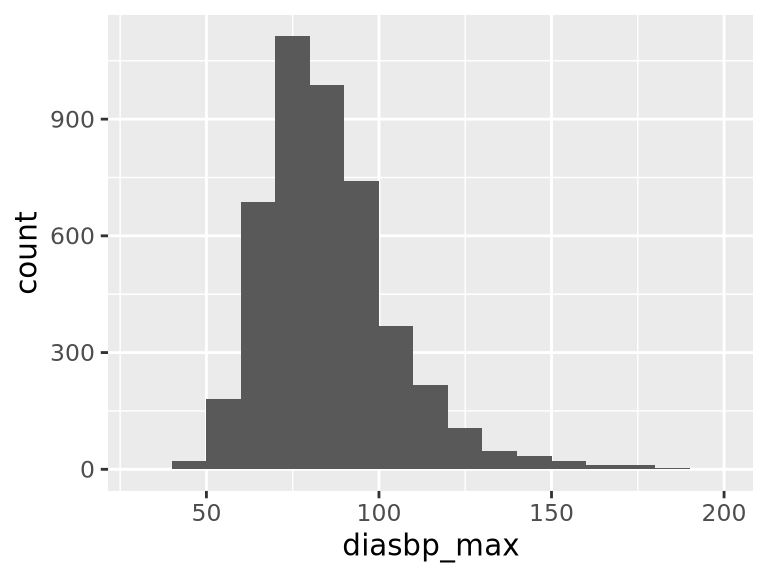

- Note that the following possible outlier values were detected: "35", "41", "44", "46", "48", …, "183", "185", "187", "196", "197" (30 values omitted).

## diasbp_mean

| Feature | Result |
| --- | --- |
| Variable type | numeric |
| Number of missing obs. | 8 (0.18 %) |
| Number of unique values | 3621 |
| Median | 60.3 |
| 1st and 3rd quartiles | 54.09; 67 |
| Min. and max. | 26.33; 129.57 |

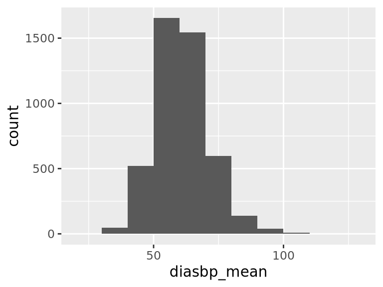

- Note that the following possible outlier values were detected: "26.33", "28.4", "32.48", "32.94", "33.43", …, "103.52", "104.29", "105.46", "107.43", "129.57" (67 values omitted).

## meanbp_min

| Feature | Result |
| --- | --- |
| Variable type | numeric |
| Number of missing obs. | 0 (0 %) |
| Number of unique values | 103 |
| Median | 56 |
| 1st and 3rd quartiles | 49; 63 |
| Min. and max. | 1; 113 |

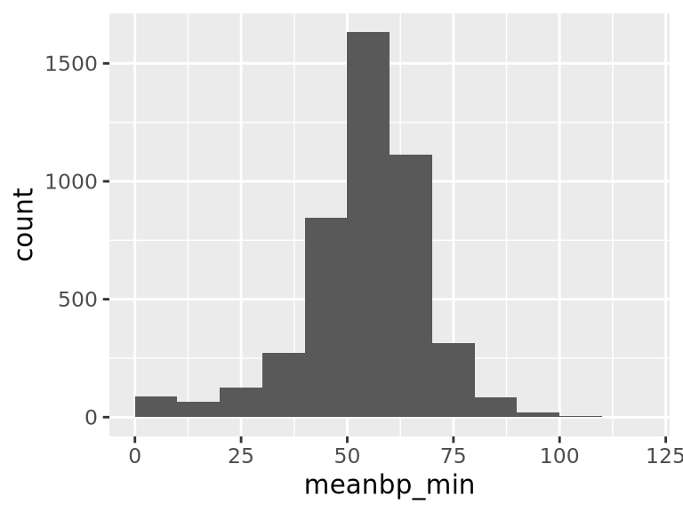

- Note that the following possible outlier values were detected: "1", "2", "3", "4", "5", …, "101", "102", "104", "109", "113" (37 values omitted).

## meanbp_max

| Feature | Result |
| --- | --- |
| Variable type | numeric |
| Number of missing obs. | 0 (0 %) |
| Number of unique values | 197 |
| Median | 101 |
| 1st and 3rd quartiles | 90; 114 |
| Min. and max. | 56; 298 |

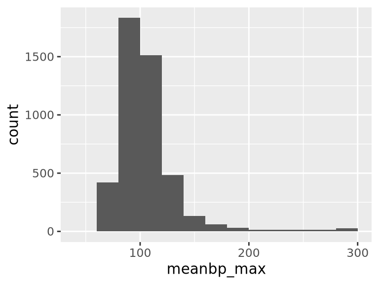

- Note that the following possible outlier values were detected: "56", "58", "60", "62", "63", …, "294", "295", "296", "297", "298" (89 values omitted).

## meanbp_mean

| Feature | Result |
| --- | --- |
| Variable type | numeric |
| Number of missing obs. | 0 (0 %) |
| Number of unique values | 3677 |
| Median | 75 |
| 1st and 3rd quartiles | 69.04; 82.41 |
| Min. and max. | 45.6; 133.16 |

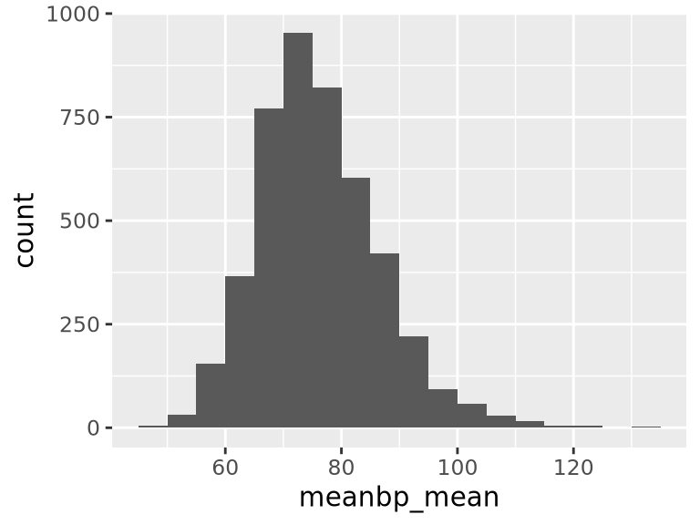

- Note that the following possible outlier values were detected: "45.6", "46.97", "48.36", "48.71", "49.83", …, "122.48", "123.21", "124.96", "131.5", "133.16" (71 values omitted).

## resprate_min

| Feature | Result |
| --- | --- |
| Variable type | numeric |
| Number of missing obs. | 1 (0.02 %) |
| Number of unique values | 30 |
| Median | 13 |
| 1st and 3rd quartiles | 10; 15 |
| Min. and max. | 1; 32 |

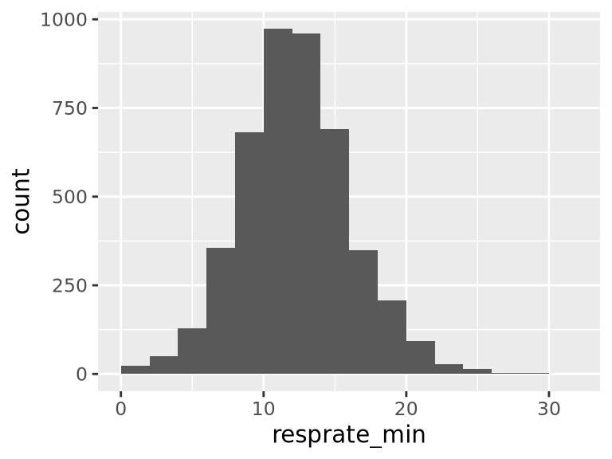

- Note that the following possible outlier values were detected: "1", "2", "23", "24", "25", "26", "27", "28", "30", "32".

## resprate_max

| Feature | Result |
| --- | --- |
| Variable type | numeric |
| Number of missing obs. | 1 (0.02 %) |
| Number of unique values | 53 |
| Median | 27 |
| 1st and 3rd quartiles | 24; 32 |
| Min. and max. | 13; 69 |

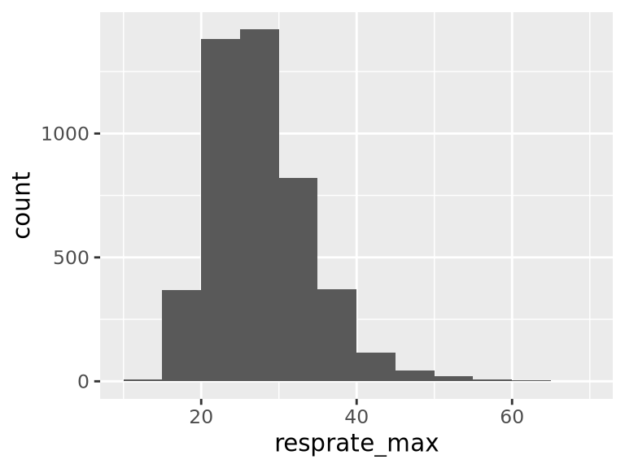

- Note that the following possible outlier values were detected: "13", "14", "15", "16", "17", …, "61", "62", "64", "68", "69" (10 values omitted).

## resprate_mean

| Feature | Result |
| --- | --- |
| Variable type | numeric |
| Number of missing obs. | 1 (0.02 %) |
| Number of unique values | 3110 |
| Median | 19.26 |
| 1st and 3rd quartiles | 16.79; 22.4 |
| Min. and max. | 9.54; 40.58 |

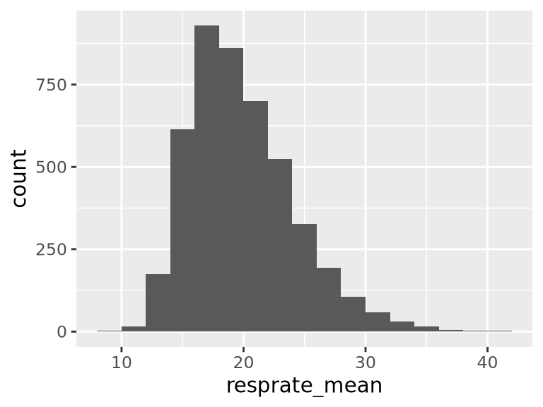

- Note that the following possible outlier values were detected: "9.54", "9.78", "10.17", "10.5", "10.79", …, "38.44", "38.96", "40.16", "40.37", "40.58" (20 values omitted).

## tempc_min

| Feature | Result |
| --- | --- |
| Variable type | numeric |
| Number of missing obs. | 103 (2.26 %) |
| Number of unique values | 167 |
| Median | 36.11 |
| 1st and 3rd quartiles | 35.61; 36.61 |
| Min. and max. | 15; 39.6 |

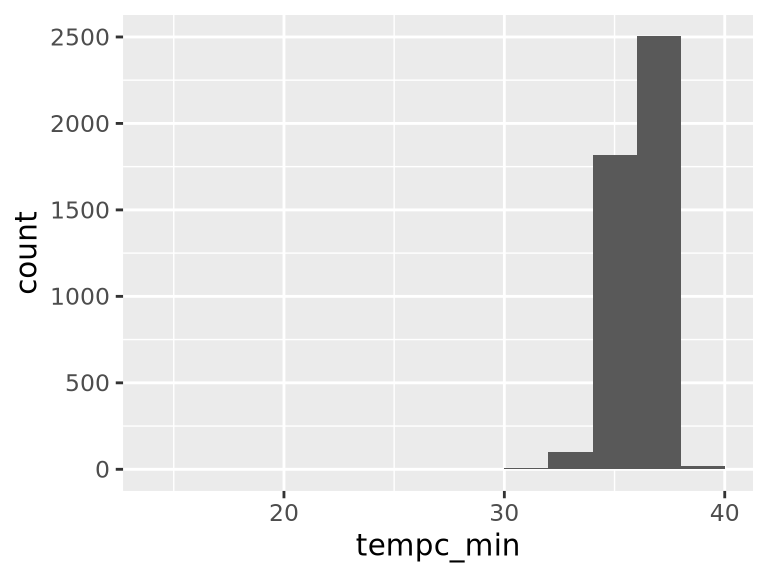

- Note that the following possible outlier values were detected: "15", "26.67", "29.44", "29.9", "30.56", …, "38.7", "38.72", "38.94", "39.2", "39.6" (53 values omitted).

## tempc_max

| Feature | Result |
| --- | --- |
| Variable type | numeric |
| Number of missing obs. | 103 (2.26 %) |
| Number of unique values | 164 |
| Median | 37.5 |
| 1st and 3rd quartiles | 37; 38.11 |
| Min. and max. | 31.6; 42 |

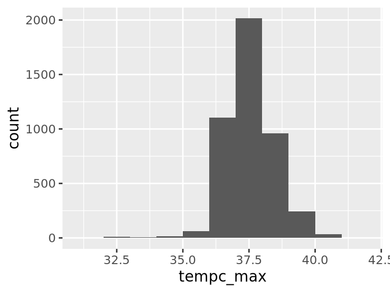

- Note that the following possible outlier values were detected: "31.6", "32.2", "32.4", "32.61", "32.7", …, "40.9", "40.94", "41.11", "41.6", "42" (39 values omitted).

## tempc_mean

| Feature | Result |
| --- | --- |
| Variable type | numeric |
| Number of missing obs. | 103 (2.26 %) |
| Number of unique values | 1692 |
| Median | 36.82 |
| 1st and 3rd quartiles | 36.41; 37.31 |
| Min. and max. | 31.6; 40.1 |

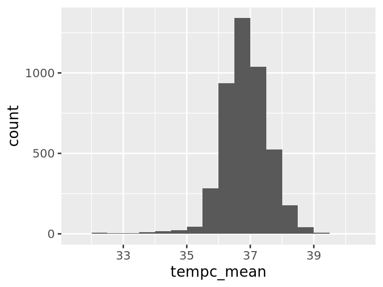

- Note that the following possible outlier values were detected: "31.6", "32.02", "32.1", "32.2", "32.35", …, "39.36", "39.45", "39.56", "39.71", "40.1" (84 values omitted).

## spo2_min

| Feature | Result |
| --- | --- |
| Variable type | numeric |
| Number of missing obs. | 1 (0.02 %) |
| Number of unique values | 71 |
| Median | 93 |
| 1st and 3rd quartiles | 90; 95 |
| Min. and max. | 1; 100 |

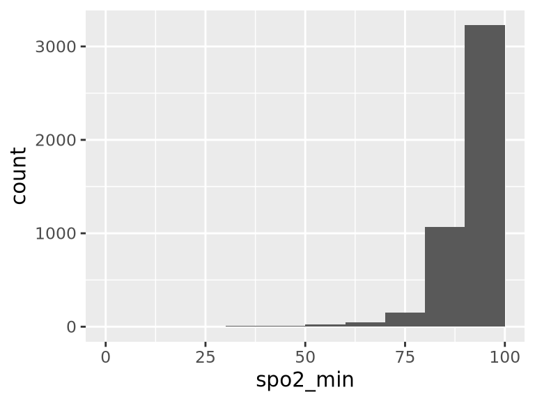

- Note that the following possible outlier values were detected: "1", "5", "11", "13", "18", …, "74", "75", "76", "99", "100" (39 values omitted).

## spo2_max

| Feature | Result |
| --- | --- |
| Variable type | numeric |
| Number of missing obs. | 1 (0.02 %) |
| Number of unique values | 12 |
| Median | 100 |
| 1st and 3rd quartiles | 100; 100 |
| Min. and max. | 89; 100 |

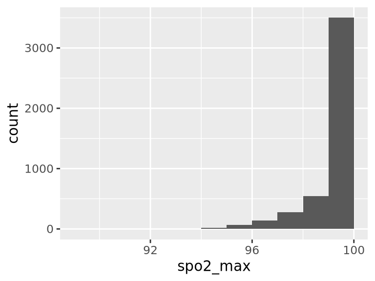

- Note that the following possible outlier values were detected: "89", "90", "91", "92", "93", …, "95", "96", "97", "98", "99" (1 values omitted).

## spo2_mean

| Feature | Result |
| --- | --- |
| Variable type | numeric |
| Number of missing obs. | 1 (0.02 %) |
| Number of unique values | 2015 |
| Median | 97.26 |
| 1st and 3rd quartiles | 95.8; 98.6 |
| Min. and max. | 55.87; 100 |

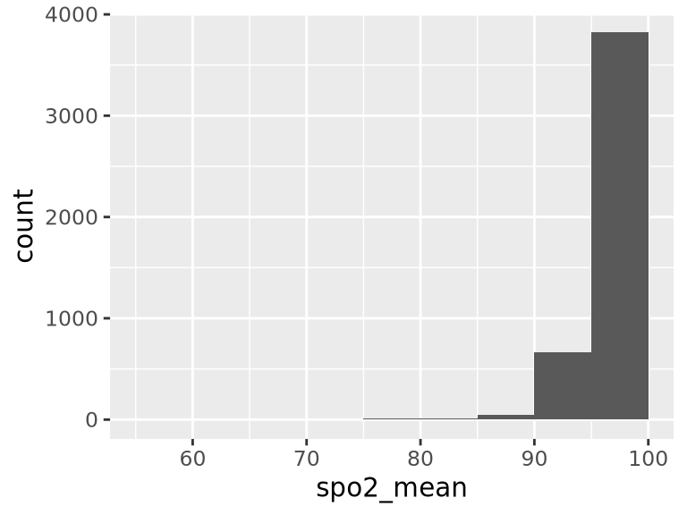

- Note that the following possible outlier values were detected: "55.87", "71.85", "76.16", "76.38", "78.08", …, "89.81", "89.96", "90", "90.07", "90.13" (55 values omitted).

## glucose_min1

| Feature | Result |
| --- | --- |
| Variable type | numeric |
| Number of missing obs. | 30 (0.66 %) |
| Number of unique values | 245 |
| Median | 106 |
| 1st and 3rd quartiles | 89; 127 |
| Min. and max. | 12; 480 |

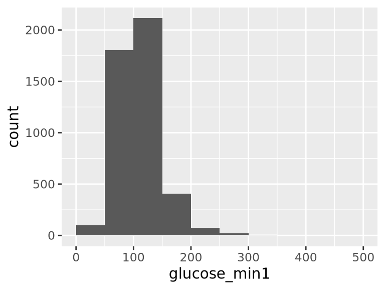

- Note that the following possible outlier values were detected: "12", "15", "16", "19", "20", …, "356", "357", "374", "424", "480" (80 values omitted).

## glucose_max1

| Feature | Result |
| --- | --- |
| Variable type | numeric |
| Number of missing obs. | 30 (0.66 %) |
| Number of unique values | 454 |
| Median | 166 |
| 1st and 3rd quartiles | 130; 217 |
| Min. and max. | 57; 999999 |

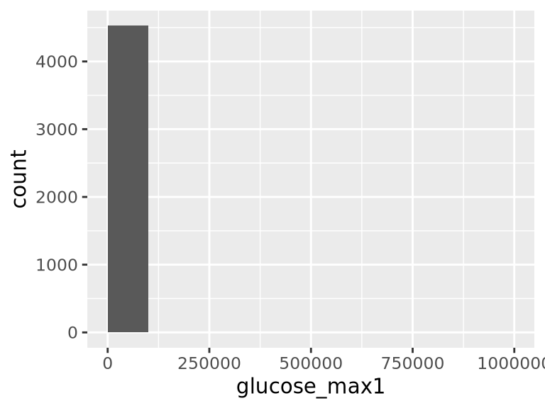

- The following suspected missing value codes enter as regular values: "999999".
- Note that the following possible outlier values were detected: "57", "62", "64", "65", "66", …, "883", "900", "1016", "1038", "999999" (62 values omitted).

## glucose_mean

| Feature | Result |
| --- | --- |
| Variable type | numeric |
| Number of missing obs. | 30 (0.66 %) |
| Number of unique values | 2228 |
| Median | 134.19 |
| 1st and 3rd quartiles | 113; 165 |
| Min. and max. | 52.44; 142966.86 |

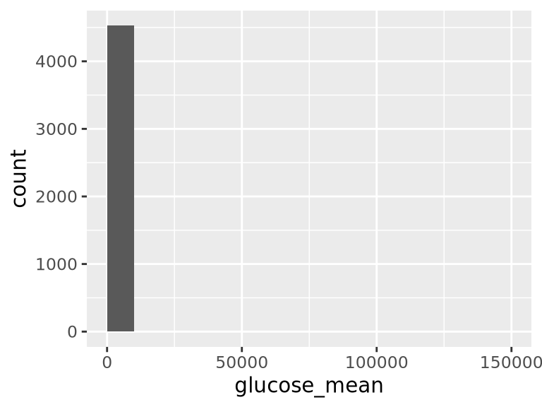

- Note that the following possible outlier values were detected: "52.44", "57", "62", "62.75", "63.07", …, "479.26", "578.25", "657", "786.22", "142966.86" (114 values omitted).

## rrt

- Note that this variable is treated as a factor variable below, as it only takes a few unique values.

| Feature | Result |
| --- | --- |
| Variable type | numeric |
| Number of missing obs. | 0 (0 %) |
| Number of unique values | 2 |
| Mode | “0” |
| Reference category | 0 |

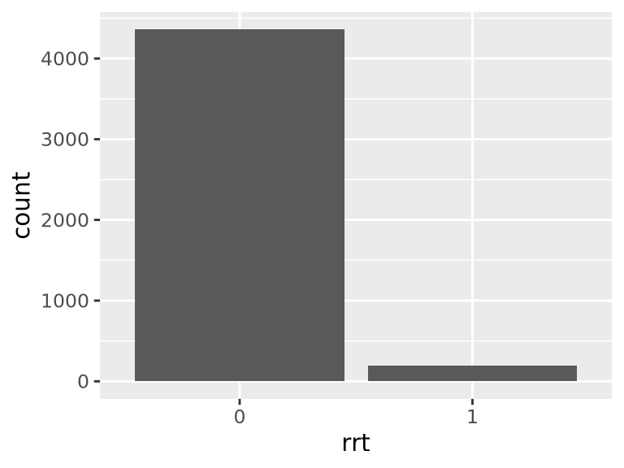

## subject_id

| Feature | Result |
| --- | --- |
| Variable type | numeric |
| Number of missing obs. | 0 (0 %) |
| Number of unique values | 4559 |
| Median | 68368 |
| 1st and 3rd quartiles | 53111.5; 83771.5 |
| Min. and max. | 165; 99982 |

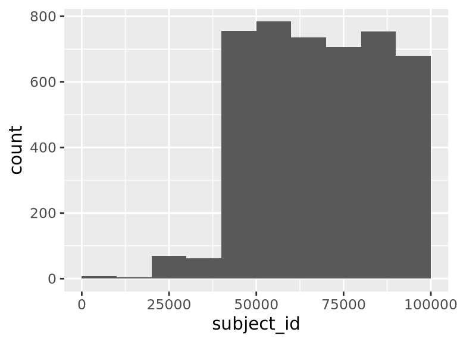

- Note that the following possible outlier values were detected: "165", "266", "671", "5771", "7310".

## hadm_id…102

| Feature | Result |
| --- | --- |
| Variable type | numeric |
| Number of missing obs. | 0 (0 %) |
| Number of unique values | 4559 |
| Median | 149643 |
| 1st and 3rd quartiles | 125389; 175033 |
| Min. and max. | 100003; 199962 |

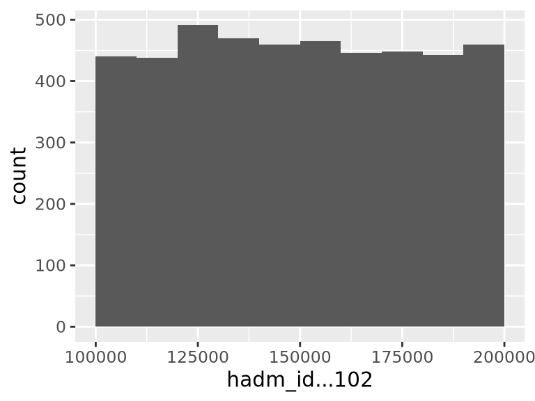

## icustay_id…103

| Feature | Result |
| --- | --- |
| Variable type | numeric |
| Number of missing obs. | 0 (0 %) |
| Number of unique values | 4559 |
| Median | 251008 |
| 1st and 3rd quartiles | 225575.5; 275526 |
| Min. and max. | 200075; 299998 |

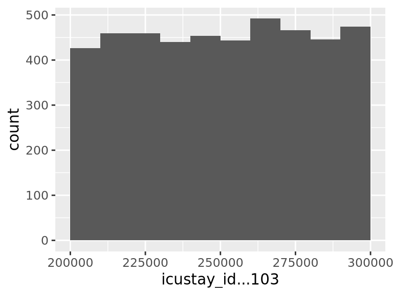

## urineoutput

| Feature | Result |
| --- | --- |
| Variable type | numeric |
| Number of missing obs. | 0 (0 %) |
| Number of unique values | 1794 |
| Median | 1560 |
| 1st and 3rd quartiles | 897.5; 2460 |
| Min. and max. | 0; 50515 |

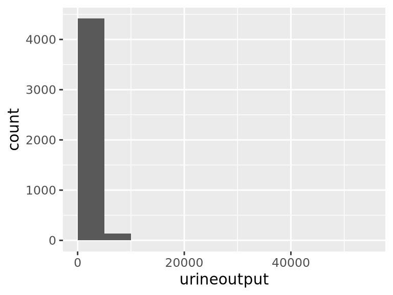

- Note that the following possible outlier values were detected: "6540", "6560", "6640", "6650", "6670", …, "9910", "10525", "11025", "12210", "50515" (34 values omitted).

## colloid_bolus

| Feature | Result |
| --- | --- |
| Variable type | numeric |
| Number of missing obs. | 4050 (88.84 %) |
| Number of unique values | 13 |
| Median | 500 |
| 1st and 3rd quartiles | 250; 500 |
| Min. and max. | 150; 1000 |

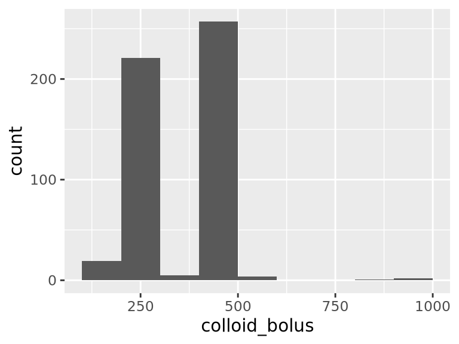

- Note that the following possible outlier values were detected: "550", "600", "900", "1000".

## crystalloid_bolus

| Feature | Result |
| --- | --- |
| Variable type | numeric |
| Number of missing obs. | 1194 (26.19 %) |
| Number of unique values | 96 |
| Median | 500 |
| 1st and 3rd quartiles | 500; 1000 |
| Min. and max. | 250; 11000 |

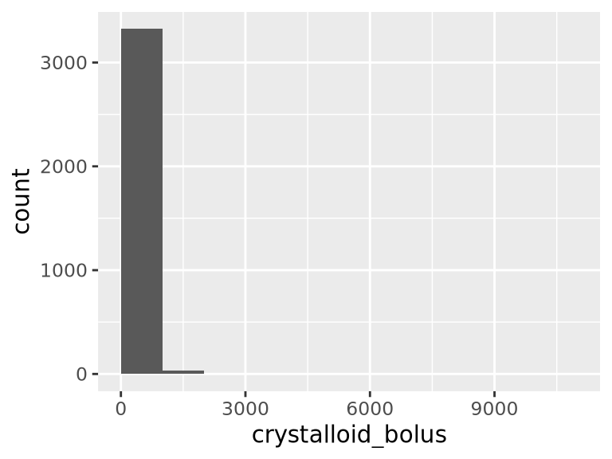

- Note that the following possible outlier values were detected: "250", "258", "267", "275", "276", …, "423", "433", "450", "467", "475" (21 values omitted).

Report generation information:

- Created by: Could not determine from system (username: `ecm20`).
- Report creation time: Sun Oct 08 2023 10:44:20
- Report was run from directory: `/home/ecm20/R/STA6257_Project_SVM/Josh Branch/STA6257_Project_SVM_Josh/Team Repo`
- dataMaid v1.4.1 [Pkg: 2021-10-08 from CRAN (R 4.3.1)]
- R version 4.3.1 (2023-06-16).
- Platform: x86_64-pc-linux-gnu (64-bit)(America/Chicago).
- Function call: `makeDataReport(data = data, output = "html", replace = TRUE)`